# Analysis of Root Data in Winter Wheat

Author

Affiliation

Henning Kage

Institute of Crop Science and Plant Breeding, Agronomy and Crop Science, Christian-Albrechts-University, Kiel, Germany

Published

May 12, 2025

Keywords

Wheat, Root

# 1 Root length and root length density

In order to estimate the water transport rate towards roots and their possible limitations it is necessary to have a realistic estimate of the total root length, its spatial an temporal variation and furthermore the distribution of water uptake over the parts of the root system. The latter point is often governed by the variation of water tension within the rooted soil layers, as during a drying phase the more densely rooted upper soil layers dry out and the water uptake than focuses on deeper soil layers.

The variation total root length of a crop over time varies between crops and for a specific crop total root length is somewhat related to the total biomass production and its influencing factors. Cereal crops may have maximum total root root length values of 10 $km^2/m^2$ or in other units 100 $[cm\ cm^{-2}]$. Especially grain legumes have much lower total root length values, down to approximately 10% of the values of cereal crops, which may lead to a value of 10 $[cm\ cm^{-2}]$ (Kage and Ehlers, 1996). For a rooting depth of 100 cm (cereal crop) this leads to an average root length density of 1 $[cm \cdot cm^{-3}]$ and for a lower rooting depth of a grain legume of about 50 [cm] we end at values of 0.2 $[cm\ cm^{-2}]$. Root length density in the subsoil, which is most important during drought stress phases, however, is much lower.

## 1.1 Dynamic of total root length

The growth of the root system is closely linked to the growth of the entire crop and to some extend and under some conditions (drought stress, nutrient deficiency) *vice* *versa*. If the fraction of dry matter increase attributed to fine root growth, ffR, is known, the increase of total fine root length dRL/dt (cm.m-2.d-1) may simply be calculated from the total dry weight increase dWt/dt $(g \cdot m^{-2} \cdot d^{-1)}$ and the average specific root length SRL $(cm\cdot g^{-1} DM)$ (Kage et al., 2000).

$$\frac{dRL}{dt}=\frac{d{{W}_{t}}}{dt}\cdot {{f}_{fR}}\cdot SRL
\tag{1}$$

The value of $f_{fR}$ may be assumed to be constant or to decrease during the plant’s development from the vegetative to the generative phase with a minimum value of zero. As a simple approximation a linear decrease of $f_{fR}$ with temperature sum since emergence may be assumed:

$$f_{fR}=\max (0,\,\,{{f}_{fR0}}-{{f}_{fRdec}}\cdot TS)
\tag{2}$$

where ffR0 (-) is the initial fraction of dry matter allocated to the root fraction and ffRdec $(°C^{-1} d^{-1})$ is the decrease of this fraction per unit of accumulated temperature. The value of SRL may regarded as a parameter or be calculated from the average diameter of the roots and the average dry matter content of the roots. A constant value of 7000 $cm\cdot g^{-1}\; DM$ is used here based on data of Barraclough (1984), nevertheless, also much lower values have been reported from soils with a quite high clay content (Savin et al., 1994; Siddique et al., 1990).

The total dry matter production rate may be estimated from the shoot dry matter increase if one considers only a fine root pool as below-ground biomass:
$$\frac{dW_t}{dt}=\frac{1}{\left( 1-{{f}_{fR}} \right)}\frac{d{{W}_{sh}}}{dt}
\tag{3}$$
Shoot dry matter increase may be obtained from a crop growth model or may be derived from an appropriate function fitted to experimental data. In this study we followed the second approach, using the Richards-function (Thornley and Johnson, 1990):

$$\frac{dW_{sh}}{dt}=r_{Ws}\cdot T_{eff} \cdot W_{sh} \cdot \left( \frac{W_{shmax}^{rf}-{W_{sh}}^{rf}}{rf\cdot W_{shmax}^{rf}} \right)
\tag{4}$$

Where $r_{Ws}$ is a growth rate parameter, $T_{eff}$ is the effective temperature, $W_{shmax}$ is the maximum attained shoot dry matter and rf is form parameter. This function can be integrated numerically, using a value for $W_{sh}$ at sowing of 10 $g\cdot m^{-2}$. The effective temperature was calculated from:

$$T_{eff}=\max \left( 0,\left( {{T}_{a}}-{{T}_{b}} \right) \right)
\tag{5}$$

Where $T_a$ is the daily average air temperature $T_b$ is a base temperature, assumed to be 4°C.

## 1.2 Rooting depth

Rooting depth zr (cm) is often found to increase linearly with accumulated temperature sum within certain development stages, but lag phases in rooting depth increase (Thorup-Kristensen, 1998; Thorup-Kristensen and Nielsen, 1998) as well as diminishing rooting depth increases during maturity (Jaafar et al., 1993) have been observed. Rooting depth increase $[cm \cdot d^{-1}]$ therefore simply is:

$$\frac{dz_r}{dt}=b_{zr}\cdot T_{eff}
\tag{6}$$
Where $b_{zr}$ $[cm\cdot°C^{-1}\cdot d^{-1}]$ is a constant. The base temperature for root growth was set to 0°C.

## 1.3 Vertical root distribution

Root length density, however, is not uniform over the soil profile. Typically it is decreasing exponentially from the highest values near the soil surface with depth (Barraclough, 1984; Gerwitz and Page, 1974; Greenwood et al., 1982):

$$L_{rv}=L_{rv0}\cdot {{e}^{-{{k}_{r}}\cdot z}}
\tag{7}$$

where the constant $k_r$ $(cm^{-1})$ is the fractional decrease in RLD per unit increase of soil depth and $L_{rv0}$ is the root length density at zero soil depth.

Integration of z=0 to a depth $z=z_r$ were the root length density is very low yields the root length RL $(cm \cdot cm^{-2})$ (see Kage et al., 2000):

$$L_r=\int\limits_{z=0}^{z=z_r}{L_{rv0}\cdot {{e}^{-{{k}_{r}}\cdot z}}\cdot dz}=\frac{L_{rv0}}{{{k}_{r}}}\cdot \left( 1-{{e}^{-{{k}_{r}}\cdot {{z}_{r}}}} \right)
\tag{8}$$

To calculate the average rooting density $\overline{L_{rv}}$ $(cm \cdot cm^{-3})$ within a certain soil layer located between two soil depths z1 and z2 the above equation may be set up for both depths.The difference between RL at z2 and z1 divided by the distance z2-z1 gives the desired value of $RLD_{av}$:

$$\overline{L_{rv}}=\frac{L_{rv0}\cdot \left( {{e}^{-{{k}_{r}}\cdot {{z}_{1}}}}-{{e}^{-{{k}_{r}}\cdot {{z}_{2}}}} \right)}{{{k}_{r}}\cdot \left( {{z}_{2}}-{{z}_{1}} \right)}
\tag{9}$$

At the moment $k_r$ and $L_{rv0}$ remain unknown parameters.

for the depth $z=z_r$ and introducing a new parameter, $r_{RLD}$, describing the ratio of RLD at $z_r$, $RLD_{zr}$, and RLD<sub>0</sub> the following identity can be found for the parameter $k_r$:

$${{k}_{r}}=-\frac{\ln \left( \frac{RL{{D}_{zr}}}{RL{{D}_{0}}} \right)}{{{z}_{r}}}=-\frac{\ln \left( {{r}_{RLD}} \right)}{{{z}_{r}}}
\tag{10}$$

Thereby, the introduction of $r_{RLD}$ avoids the necessity of using an iterative solution of the above set of equations.

Knowing this value the root length density at the soil surface can be calculated:

$$RLD_{0}=RL\cdot k_{r}\frac{1}{1-e^{-{k_r}\cdot z_r}}
\tag{11}$$

For late sown winter wheat on a loess loam soil (Kage, 2001) estimated values for $L_{rv0}$ of about 4 $cm \cdot cm^{-3}$ and $K_r$ of about 0.03.

```r
# Root length density at depth 0
Lrv0 <- 4 # cm.cm-3

# depth Lrv decrease parameter
kr <- 0.03

# sequence of depths
z <- seq(0, 150, 5)

# sequence of root length densities
Lrv <- Lrv0*exp(-kr*z)
#plot(Lrv, -z )
# integration over depth gives total root length per area
Lr <- Lrv0/kr*(1-exp(-kr*max(z)))
#cat("For these values of Lrv0 and kr the total root length is", format(Lr, digits=4), "cm/cm2.")
```

For these values of $L_{rv0}$ and $k_r$ the total root length is 131.9 $cm\cdot cm^{-2}$.

During a drying cycle, the water uptake front moves downward as the topsoil then is depleted of soil water and the majority of soil water uptake may take happen in a quite narrow soil volume. If we assume that all water is taken up from the soil depth 60 to 80 cm.

For this depth we have an average root length density ($L_{rv}$) of 0.5 $[cm \cdot cm^{-3}]$ and root length for water uptake $(L_r)$ of 9.9 $[cm \cdot cm^{-2}]$. Therefore the water uptake per unit root length or water influx rate $I_w$ is 0.05 $[cm^3 \cdot cm \cdot d^{-1}]$. The peak value of water uptake around noon is about 2.5 the value of the average influx rate, $I_{w,max}$ therefore is about 0.13 $[cm \cdot d^{-1}]$.

For very low values of $L_{rv}$ in combination with low unsaturated hydraulic conductivity of the soil, however, the water uptake may be limited the transport rate towards the root.

# 2 Parameterisation of simple descriptive root growth model / Analysis of root data winter wheat crop rotation experiment Ruthe 1995-1997

The data originate from a crop rotation system experiment conducted at the Ruthe experimental station, located south of Hanover on a loess loam site.

## 2.1 Experimental design

Field experiment, 4-factorial in split-plot design

### 2.1.1 Factors/Treatments

1st Factor: Rotations (R) horticultural crop rotation, intensive agricultural crop rotation, extensive

2nd Factor: Crop types (A) Years horticultural crop rotation, agricultural crop rotation

3rd Factor: Soil cultivation (B) B1: Plow: intensive, inverting B2: Rotary tiller: extensive, mixing

4th Factor: Nitrogen fertilization (N) N1: Official recommendation N2: Official recommendation - 30%

3 replications

N fertilisation is a sub unit of crop rotation / crop.

## 2.2 Methods

The root data observation contains soil core and Minirhizotron method. The soil core method severed as reference method for the Minirhizotron method. The soil core data were used to determine the root length density (RLD) in cm/cm³.

## 2.3 Soil core data

Soil cores have been taken in 15 cm intervals and root length density (RLD) has been determined from length estimates based on the Newman methods. RLD then is given per volume of soil (cm/cm³). Maximum depth of observations was 120cm.

### 2.3.1 Data import

```r
## soil core data ----

sc <- read.csv("soilcores.csv")
sc$Date <- as.Date(sc$Datum, origin = "1899-12-30")

# rename columns and factor levels
sc <- sc %>% dplyr::rename("Depth"="Tiefe", "Nrate"="Nduengung", "CR"="FRUFOL", "Year"="Jahr", "Depth2"="Tiefe2")
sc <- sc %>% mutate(CR = case_when(
  CR == "Gemüse" ~ "Veg",
  CR == "Agrar" ~ "Ag",
  TRUE ~ as.character(CR)
))
sc <- sc %>% mutate(Nrate = case_when(
  Nrate == "ohne N" ~ "NoN",
  Nrate == "normal" ~ "norm",
  Nrate == "reduziert" ~ "red",
  TRUE ~ as.character(CR)
))

sc <- sc %>% mutate(DepthStr = case_when(
  Depth == 15 ~ "  0-15",
  Depth == 30 ~ " 15-30",
  Depth == 45 ~ " 30-45",
  Depth == 60 ~ " 45-60",
  Depth == 75 ~ " 60-75",
  Depth == 90 ~ " 75-90",
  Depth == 105 ~ " 90-105",
  Depth == 120 ~ "105-120"
))


#sc %>% group_by(Jahr) %>% str()
#str(sc)
```

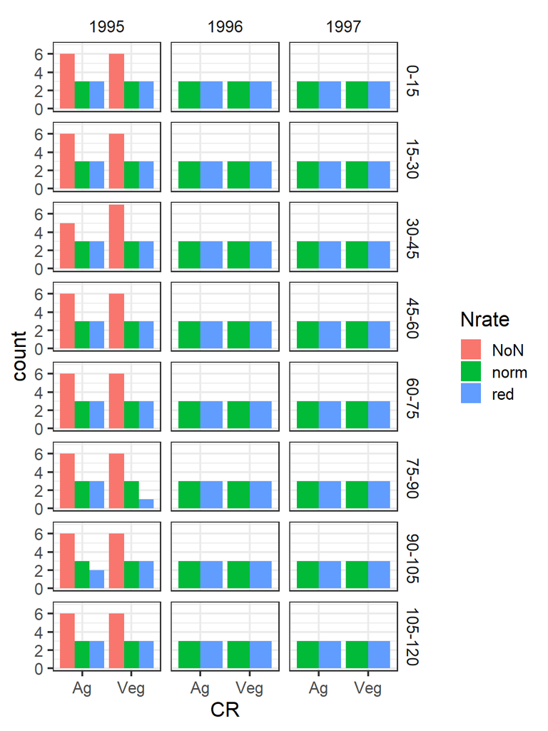

Figure 1: Number of soil core data per year, depth, N fertilisation and crop rotation

```r
# remove cores from plots without N fertilization
sc <- sc[sc$Nrate!="NoN",]
# remove data with infinite values of lnWLD
sc2 <- sc[is.finite(sc$lnWLD),]

# create factors for variance analysis of the repeated measurement split-plot design
sc2$YearBlock <- as.factor(paste(sc2$Year,sc2$BLOCK, sep="_"))
sc2$MainPlot <- as.factor(paste(sc2$Year, sc2$BLOCK, sc2$CR, sep="_"))
sc2$Nrate <- factor(sc2$Nrate)
```

### 2.3.2 Anova

An analysis of variance was performed to investigate the effects of year, N fertilization and depth on log transformed root length density. It has to be noted that depth was included as a numerical variable in the model. The root length density data have been log transformed to obtain a normal distribution. The analysis of variance was performed using the `lme` function from the `nlme` package. The model includes the fixed effects of year, N fertilisation, crop rotation and depth as well as their interactions. The random effects include the block and main plot structure of the split-plot design. Model 1 does not consider a correction for the variance structure, model 2 considers the variance structure. The depth effects on the variance structure were considered by using a variance structure of the form varIdent.

```r
## anova -----


### without correction for depth effects on variance
modMix1 <- lme(lnWLD ~ Year * CR * Nrate*Depth2,
                 random = ~1|YearBlock/MainPlot,
                 data = sc2)
```

```r
library(car)
Anova(modMix1)
```

```
Analysis of Deviance Table (Type II tests)

Response: lnWLD
                        Chisq Df Pr(>Chisq)
Year                   2.6103  1   0.106170
CR                     2.3922  4   0.664039
Nrate                  6.7844  4   0.147730
Depth2               546.2896  4  < 2.2e-16 ***
Year:CR                1.7280  1   0.188668
Year:Nrate             0.4132  1   0.520360
CR:Nrate               1.1929  2   0.550759
Year:Depth2            6.8274  1   0.008977 **
CR:Depth2              0.1141  2   0.944545
Nrate:Depth2           3.2759  2   0.194377
Year:CR:Nrate          4.7514  1   0.029274 *
Year:CR:Depth2         0.1054  1   0.745435
Year:Nrate:Depth2      0.0035  1   0.952921
CR:Nrate:Depth2        0.0335  1   0.854768
Year:CR:Nrate:Depth2   2.7737  1   0.095823 .
---
Signif. codes:  0 '***' 0.001 '**' 0.01 '*' 0.05 '.' 0.1 ' ' 1
```

A more simplified model with only the main effects and the interaction of year and depth was fitted. The model is given below.

```r
### with correction for year effects on variance #

modMix2 <- lme(lnWLD ~ Year*Depth2+ Nrate:Depth2,
               random = ~1|YearBlock/MainPlot,
               data = sc2,
               weights = varIdent(form = ~1|Depth2))
Anova(modMix2)
```

```
Analysis of Deviance Table (Type II tests)

Response: lnWLD
                Chisq Df Pr(>Chisq)
Year           8.3876  1   0.003778 **
Depth2       701.7296  1  < 2.2e-16 ***
Year:Depth2    1.1382  1   0.286036
Depth2:Nrate   2.5807  1   0.108176
---
Signif. codes:  0 '***' 0.001 '**' 0.01 '*' 0.05 '.' 0.1 ' ' 1
```

The two models are compared using the Akaike Information Criterion (AIC). The model with the lower AIC value is usually preferred.

```r
## comparison of models
AIC(modMix1, modMix2)
```

```
        df      AIC
modMix1 19 947.0042
modMix2 15 841.9845
```

```r
summary(modMix2)
```

```
Linear mixed-effects model fit by REML
  Data: sc2
       AIC      BIC    logLik
  841.9845 896.4527 -405.9923

Random effects:
 Formula: ~1 | YearBlock
        (Intercept)
StdDev:   0.2236246

 Formula: ~1 | MainPlot %in% YearBlock
        (Intercept)  Residual
StdDev:   0.1325925 0.3782737

Variance function:
 Structure: Different standard deviations per stratum
 Formula: ~1 | Depth2
 Parameter estimates:
     7.5     22.5     37.5     52.5     67.5     82.5     97.5    112.5
1.000000 1.679549 1.922371 2.418174 3.282496 3.582849 4.141493 3.535232
Fixed effects:  lnWLD ~ Year * Depth2 + Nrate:Depth2
                    Value Std.Error  DF   t-value p-value
(Intercept)     -763.8020 248.99478 263 -3.067542  0.0024
Year               0.3833   0.12475   7  3.072632  0.0180
Depth2             3.9149   3.70858 263  1.055646  0.2921
Year:Depth2       -0.0020   0.00186 263 -1.066859  0.2870
Depth2:Nratered    0.0034   0.00212 263  1.606447  0.1094
 Correlation:
                (Intr) Year   Depth2 Yr:Dp2
Year            -1.000
Depth2          -0.433  0.433
Year:Depth2      0.433 -0.433 -1.000
Depth2:Nratered -0.006  0.006  0.026 -0.026

Standardized Within-Group Residuals:
       Min         Q1        Med         Q3        Max
-2.7758044 -0.5634991  0.1363891  0.7389547  1.8745033

Number of Observations: 284
Number of Groups:
              YearBlock MainPlot %in% YearBlock
                      9                      18
```

```r
#plot(modMix2)
```

### 2.3.3 Plot of root length density vs. depth

The simple empirical model fitted in the section before is used to predict the root length density (RLD) as a function of depth and N fertilization. The model is fitted to the data and the predictions and data are plotted in Figure 2. The fit is not perfect, but the general assumption of a logarithmic decrease of RLD with depth is confirmed.

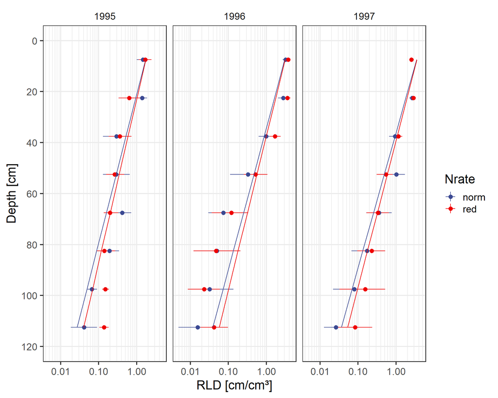

Figure 2: Root length densities of winter wheat at ear emergence to flowering grown in 3 consecutive years on a loess loam soil in northern Germany under ‘normal’ (Norm) and ‘reduced’ (Red) nitrogen fertilisation. Date were determined using the soil core method

```r
# Add model predictions to the data frame
sc2$lnWLD_pred <- predict(modMix2, newdata = sc2)
# back transformation to non log scale
sc2$WLD_pred <- exp(sc2$lnWLD_pred)

sc_av <- sc2 %>% dplyr::group_by(Year, Nrate, Depth2) %>% dplyr::summarise(WLD = mean(WLD_pred))

minor_breaks <- rep(1:9, 21)*(10^rep(-10:10, each=9))
MyBreaks <- c(1e-7, 0.000001,0.00001,0.0001,0.001, 0.01, 0.1, 1, 10, 100, 1000, 10000)

p <- ggplot(data = sc2, aes(x=Depth2, y=WLD, fill=Nrate, color=Nrate))
p <- p + stat_summary( fun.data="mean_cl_boot", size=0.5)
p <- p + geom_line(data=sc_av, aes(x=Depth2, y=WLD, color=Nrate))
#p <- p + facet_grid( cols = vars(Year), rows=vars(FRUFOL)  )
  p <- p + facet_wrap( facets = vars(Year), nrow = 1  )
p <- p + theme_bw(base_size = 18)
#p <- p + scale_x_continuous(limits = c(0,120))
p <- p + scale_y_log10(breaks = MyBreaks, minor_breaks=minor_breaks)
p <- p + scale_x_reverse(limits = c(120,0), breaks = seq(0, 120, 20))
p <- p + scale_color_aaas()
p <- p + xlab("Depth [cm]") + ylab("RLD [cm/cm³]")
p <- p + scale_shape_manual(values = MyShapes)
p <- p + coord_flip()
#p <- p + annotation_logticks(sides = "trbl")
p <- p + scale_fill_aaas()
p <- p + theme( panel.grid.minor.y = element_blank(), strip.background = element_blank() )
p
#ggsave(filename = "soilcorewldmod.png", width = 14, height = 7, dpi = 600)
```

## 2.4 Minirhizotron data

Two minirhizotron tubes made from polyacryl with an outer diameter of 4.6 cm and a total length of 180 cm were installed per plot at an angle deviating 30° from the vertical direction to avoid preferential root growth along the tubes (Bragg et al., 1983). Root observations were directly converted into root scores according to (Maertens, 1987) at the field plot. There were two view direction, each deviating 45° from the vertical and observations were made for 5 cm depth increments. For correlation with the soil core data the score values were pooled according to the spatial aggregation of soil core data.

```r
mr <- read.csv("mr.csv", sep = ",", encoding = "UTF-8")

mr <- mr %>% dplyr::rename("Nrate"="Nduengung", "CR"="FRUFOL", "Year"="Jahr", "Depth"="TK")

mr$Date <- as.Date(mr$Datum, origin = "1899-12-30")
mr <- mr %>% mutate(CR = case_when(
  CR == "Gemüse" ~ "Veg",
  CR == "Agrar" ~ "Ag",
  TRUE ~ as.character(CR)
))

#summary(mr$Date)
#unique(mr$Date)
```

The minirhizotron data show a different vertical distribution than the soil core data (Figure 2, Figure 3). For the upper soil layers the relative score is lower than for the soil layers below the plow layer. This is presumably an artifact of the method. Later on the data from the minirhizotron data of the upper 30 cm are discarded.

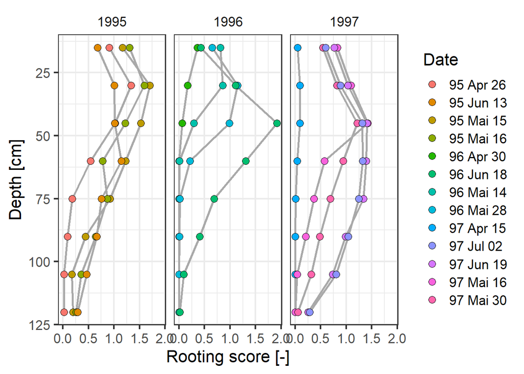

Figure 3: Root length density scores of winter wheat observed in minirhizotrones from three years in northern Germany.

```r
illu <- mr
illu$Year <- as.factor(illu$Year)
illu$Termin <- as.factor(illu$Termin)
illu <- illu %>% group_by(Year, Date, Termin, Depth) %>% dplyr::summarise(score = mean(Bonitur, na.rm=T), sd=sd(Bonitur, na.rm=T))
illu$Date2 <-  format(illu$Date, "%y %b %d")


p <- ggplot(data = illu )
p <- p + theme_bw(base_size = 16)
p <- p + geom_line(aes(x=Depth, y=score, groups=Date2), color="darkgrey",size=1)
p <- p + geom_point(aes(x=Depth, y=score, fill=Date2),shape=21, size=3)
p <- p + coord_flip()
p <- p + scale_x_reverse()
p <- p + facet_wrap(facets = vars(Year), nrow = 1)
p <- p + guides(fill=guide_legend(title="Date"))
p <- p + theme(strip.background = element_blank())
p <- p + xlab("Depth [cm]") + ylab("Rooting score [-]")
p
```

### 2.4.1 Dynamics of rooting depth from minirhizotron data

The rooting depth was determined from the minirhizotron data. The rooting depth was calculated from the minimum rooting score for each date and depth.

```r
# select the minimum rooting score for each date
mr.depth  <- illu %>% filter (score>0)%>% group_by(Termin) %>%  slice(which.min(score))

# select the first date when that depth is reached
mr.depth2 <- mr.depth %>% group_by(Year, Depth) %>% slice(which.min(Termin))


# read dates of experimental activities
ActivityDates <- read.delim("ActivityDates.csv", sep = ";", encoding = "UTF-8")

# select the dates of minirhizotron observations
mr.obs.dates <- ActivityDates %>% filter(Activity=="MRObs")

# read weather data for the experimental site
Weather <- read.csv("WeatherRuthe1994_1997.csv", sep = ";", encoding = "UTF-8")

# select the dates of sowing
SowingDates <- ActivityDates %>% filter(Activity=="Sowing")

# select the sowing time for 1995
SowingTime95 <- SowingDates[SowingDates$HarvestYear==1995,"Date"]

# create dfs for temperature sum from sowing for each year
# first for 1995
TSum95 <- Weather %>% filter(Time>=SowingTime95, Time <= SowingTime95+300) %>% dplyr::select(Time, TMPM)
# base temperature for rooting depth increase
Tbase <- 0
# temperature sum from sowing
TSum95$Tsum <- cumsum(pmax(Tbase,TSum95$TMPM))
TSum95$HarvestYear <- 1995

# the other years
SowingTime96 <- SowingDates[SowingDates$HarvestYear==1996,"Date"]
TSum96 <- Weather %>% filter(Time>=SowingTime96, Time <= SowingTime96+300) %>% dplyr::select(Time, TMPM)
Tbase <- 0
TSum96$Tsum <- cumsum(pmax(Tbase,TSum96$TMPM))
TSum96$HarvestYear <- 1996

SowingTime97 <- SowingDates[SowingDates$HarvestYear==1997,"Date"]
TSum97 <- Weather %>% filter(Time>=SowingTime97, Time <= SowingTime97+300) %>% dplyr::select(Time, TMPM)
Tbase <- 0
TSum97$Tsum <- cumsum(pmax(Tbase,TSum97$TMPM))
TSum97$HarvestYear <- 1997

# merge the data frames for all years
TSum <- rbind(TSum95, TSum96, TSum97)
TSum$Date <- as.Date(TSum$Time, origin = "1899-12-30")

# combine the minirhizotrone data with the temperature sum data
mr.depth <- merge(mr.depth2, TSum, by=c("Date"), all.x=TRUE)
```

### 2.4.2 Linear model for rooting depth increase

From the minirhizotron data we can estimate the rooting depth increase as a function of temperature sum. The rooting depth increase is assumed to be linear with temperature sum. The model is fitted to the data and the parameters are estimated.

```r
mr.depth$Year <- as.factor(mr.depth$HarvestYear)

# we assume that at sowing the rooting depth is 0 cm
mod.zr <- lm(Depth ~ 0 + Tsum, data=mr.depth)
summary(mod.zr)
```

```
Call:
lm(formula = Depth ~ 0 + Tsum, data = mr.depth)

Residuals:
   Min     1Q Median     3Q    Max
-8.437 -2.290 -2.199  5.290  6.375

Coefficients:
     Estimate Std. Error t value Pr(>|t|)
Tsum 0.107198   0.001993   53.77 1.59e-11 ***
---
Signif. codes:  0 '***' 0.001 '**' 0.01 '*' 0.05 '.' 0.1 ' ' 1

Residual standard error: 5.401 on 8 degrees of freedom
Multiple R-squared:  0.9972,    Adjusted R-squared:  0.9969
F-statistic:  2892 on 1 and 8 DF,  p-value: 1.586e-11
```

```r
# save the parameter for the rooting depth increase
k_zr <- coef(mod.zr)[1]
```

From the regression analysis we obtain the increase of rooting depth per temperature sum unit as 0.11 $\left[ cm^.°C^{-1}d^{-1} \right]$. The estimated and predicted rooting depth is shown in Figure 4.

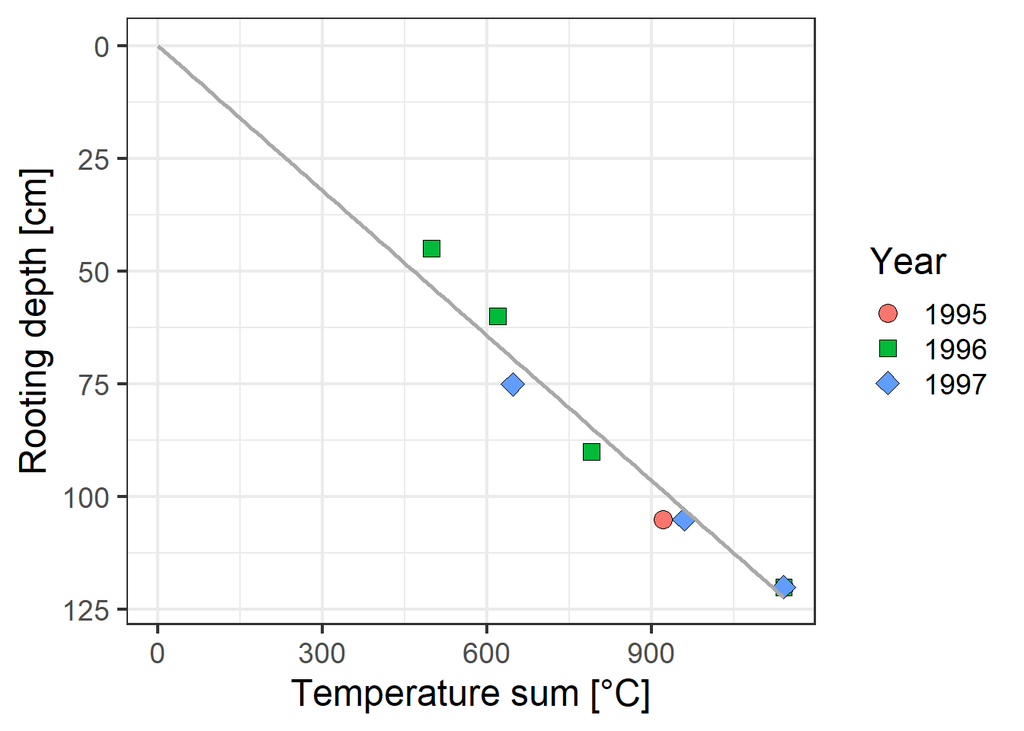

```r
df.pred <- data.frame(Tsum = seq(0, max(mr.depth$Tsum), 10))
df.pred$Depth <- predict(mod.zr, newdata = df.pred)
MyShapes <- c(21,22,23,24,25)

p <- ggplot(data = mr.depth)
p <- p + theme_bw(base_size = 18)
p <- p + geom_point(aes(x=Tsum, y=Depth, fill=Year, shape=Year), size=4)
p <- p + geom_line(data = df.pred, aes(x=Tsum, y=Depth), color="darkgrey", size=1)
p <- p + scale_shape_manual(values = MyShapes)
p <- p + ylab("Rooting depth [cm]") + xlab("Temperature sum [°C]")
#p <- p + coord_flip()
p <- p + scale_y_reverse()
p
```

## 2.5 Calibration of minirhizotron data

In order to estimate root length density from the minirhizotron data, we need to calibrate the minirhizotron data with the soil core data. The calibration is done by fitting a quadratic model without intercept to the data.

```r
#unique(mr$Date)
#unique(sc$Date)
# the dates of corresponding soil core data
library(knitr)
dates.mr.calib <- c("1995-06-13",  "1996-06-18", "1997-06-19")
mr.calib <- mr[mr$Date %in% dates.mr.calib,]
mr.calib <- mr.calib %>%  filter(Depth>30) %>% group_by(Year, Termin, Depth) %>%  dplyr::summarise(mean = mean(Bonitur, na.rm=T), sd=sd(Bonitur, na.rm=T))

sc.calib <- sc %>% filter(Depth>30) %>% group_by(Year, Depth) %>% dplyr::summarise(mean.sc = mean(WLD, na.rm=T), sd.sc=sd(WLD, na.rm=T))

calib <- merge(mr.calib, sc.calib, by=c("Year", "Depth"), all=TRUE)
calib <- calib %>% filter(mean>0, mean.sc>0)
calib$mean2 <- calib$mean^2

# We choose a model with zero intercept and a quadratic term for the mean rooting score
mod <- lm(mean.sc ~ 0 + mean + mean2, data=calib)
```

```r
kable(anova(mod))
```

ANOVA table for the calibration model for minirhizotron soreces to soil core root length density.

|  | Df | Sum Sq | Mean Sq | F value | Pr(>F) |
| --- | --- | --- | --- | --- | --- |
| mean | 1 | 5.4766040 | 5.4766040 | 368.05308 | 0.0000000 |
| mean2 | 1 | 0.3561272 | 0.3561272 | 23.93339 | 0.0001628 |
| Residuals | 16 | 0.2380789 | 0.0148799 | NA | NA |

```r
summary(mod)
```

```
Call:
lm(formula = mean.sc ~ 0 + mean + mean2, data = calib)

Residuals:
     Min       1Q   Median       3Q      Max
-0.24688 -0.03243  0.02365  0.05860  0.28268

Coefficients:
      Estimate Std. Error t value Pr(>|t|)
mean   0.10058    0.10017   1.004 0.330233
mean2  0.35580    0.07273   4.892 0.000163 ***
---
Signif. codes:  0 '***' 0.001 '**' 0.01 '*' 0.05 '.' 0.1 ' ' 1

Residual standard error: 0.122 on 16 degrees of freedom
Multiple R-squared:  0.9608,    Adjusted R-squared:  0.9559
F-statistic:   196 on 2 and 16 DF,  p-value: 5.595e-12
```

The linear and quadratic terms of the model are estimated at 0.1 and 0.36, respectively. The measured and predicted data are shown in Figure 5. Note that the data have been averaged over all treatments.

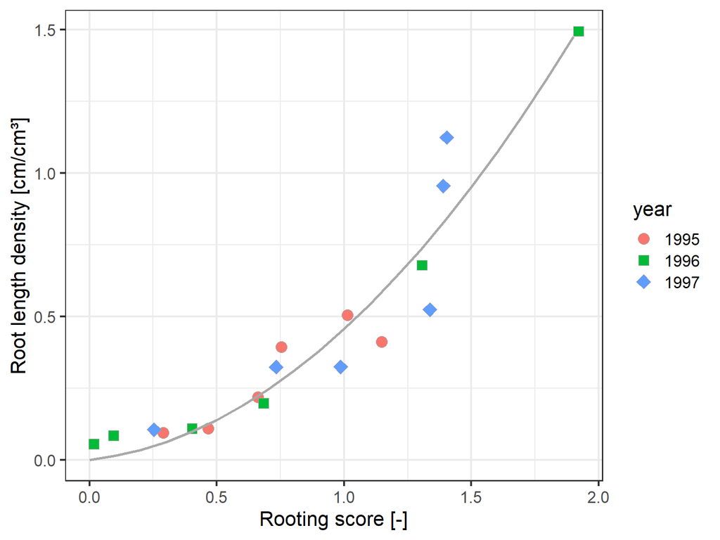

Figure 5: Correlation between root length density scores (rsc) from minirhizotron observations and root length density (RLD) of winter wheat from soil depths > 30 cm as determined by soil core measurements for three years on a silt loam soil.

```r
df.pred <- data.frame(mean = seq(0, max(calib$mean), 0.1))
df.pred$mean2 <- df.pred$mean^2
df.pred$mean.sc <- predict(mod, newdata = df.pred)
calib$year <- as.factor(calib$Year)

p <- ggplot()
p <- p + theme_bw(base_size = 16)
p <- p + geom_point(data = calib, aes(y=mean.sc, x=mean, fill=year, shape=year), color="darkgrey", size=4)
p <- p + geom_line(data = df.pred, aes(y=mean.sc, x=mean), color="darkgrey", size=1)
p <- p + scale_shape_manual(values = MyShapes)
p <- p + xlab("Rooting score [-]") + ylab("Root length density [cm/cm³]")
p
```

```r
# make a copy of the minirhizotron data
mr.av <- mr
#unique(mr.av$Date)

# average the minirhizotron data for date, Nrate and depth
mr.av$Termin <- as.factor(mr.av$Termin)
mr.av <- mr.av %>% group_by(Year, Date, Termin, Nrate, Depth) %>% dplyr::summarise(score = mean(Bonitur, na.rm=T), sd=sd(Bonitur, na.rm=T))
# a date format for plotting
mr.av$Date2 <-  format(mr.av$Date, "%d %b")

# deselect all minirhizotron data from the upper 30 cm
mr.av <- mr.av %>% filter(Depth>30)

# calculated the root length density from the minirhizotron scores
mr.av$rld = coef(mod)[1]*mr.av$score +coef(mod)[2]*mr.av$score^2
#summary(mr.av$rld)

#mr$Depth <- as.factor(mr$Depth)

#unique(mr.av$Date)
# mark the data as minirhizotron data
mr.av$method <- "minirhizotron"

# take the soil core data and rename WLD to rld
tmp <- sc2 %>% select(Year, Date, Nrate, Depth, Date, WLD)  %>% dplyr::rename("rld"="WLD")
tmp <- tmp %>% group_by(Year, Date, Nrate, Depth) %>% dplyr::summarise(rld = mean(rld, na.rm=T))
# mark the data as soil core data
tmp$method <- "soil core"
#unique(tmp$Date)

mr.av <- mr.av %>% select(Year, Nrate, Depth, Date, rld, method)

# combine the minirhizotron data with the soil core data for use in parameter estimation
rld.data <- rbind(mr.av, tmp)
#unique(rld.data$Date)

# create a depth variable with middle of the depth interval
rld.data$Depth2 <- rld.data$Depth-15

rld.data <- rld.data %>% filter(rld >0)


# create ranks of the observation dates per year for plotting
# create a date variable for day of the the year
rld.data$DOY <- as.numeric(format(rld.data$Date, "%j"))

library(data.table)

dt <- as.data.table(rld.data)
#dt <- dt[, .SD[sample(.N, .N)]] # reorder the rows to mimic unordered case
dt <- dt[order(Year, DOY),]
# without grouping
dt[, rank :=  rleid(DOY)]
# with grouping
dt[, rank :=  rleid(DOY), by=Year]

rld.data <- as.data.frame(dt)
#unique(rld.data$Date)

#summary(rld.data$rank)
```

The combined data for root length density from the minirhizotron and soil core data are shown in Figure 6. The data are shown for the years 1995-1997 and for the N fertilisation levels “normal” and “reduced”. The data are shown as function of depth and date. The data are shown on a log scale.

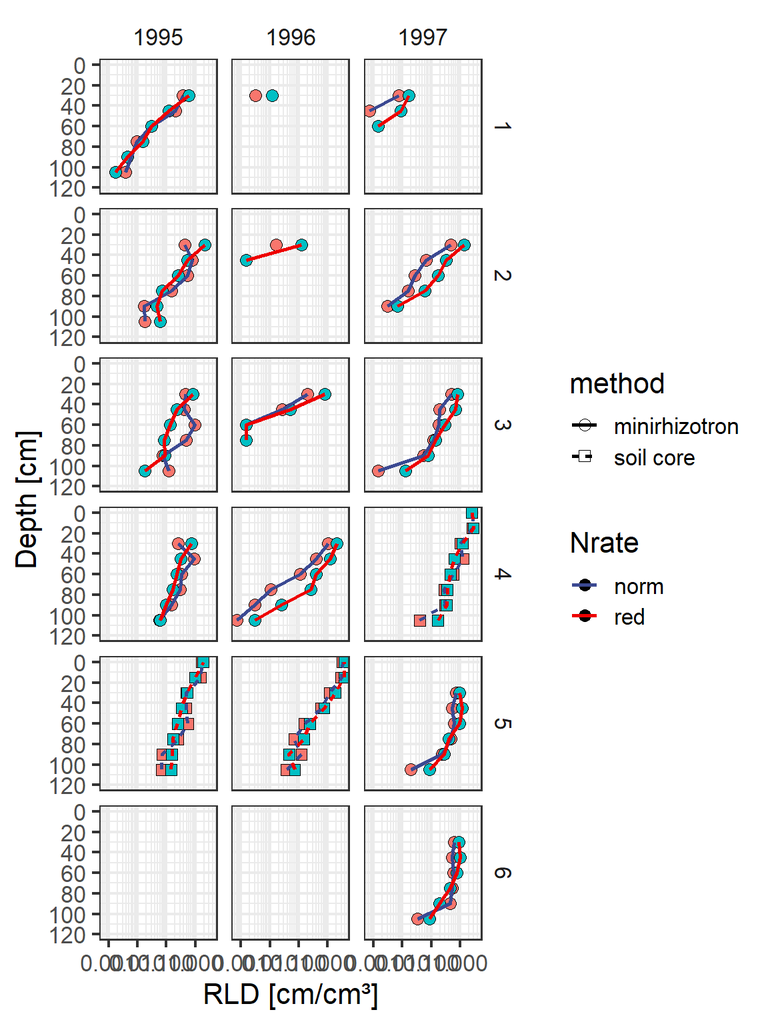

Figure 6: Root length density (RLD) in cm/cm³ as function of date and N fertilisation

```r
p <- ggplot(data = rld.data)
p <- p + theme_bw(base_size = 16)
p <- p + geom_point(aes(x=Depth2, y=rld, fill=Nrate, shape=method), size=3)
p <- p + geom_line(aes(x=Depth2, y=rld, color=Nrate, linetype = method), size=1)
p <- p + facet_grid(cols =vars(Year), rows=vars(rank)  )
#p <- p + facet_wrap(facets =vars(Date), ncol=3  )
p <- p + scale_shape_manual(values = MyShapes)
p <- p + scale_color_aaas()
p <- p + scale_x_reverse(limits = c(120,0), breaks = seq(0, 120, 20))
p <- p + scale_y_log10(breaks = MyBreaks, minor_breaks=minor_breaks)
p <- p + coord_flip()
p <- p + xlab("Depth [cm]") + ylab("RLD [cm/cm³]")
p <- p + theme(strip.background = element_blank())
p
```

## 2.6 Shoot growth

For the dynamics of total root length we need the daily shoot dry matter growth rate $dW/dt$. The shoot dry matter increase was determined from the shoot dry matter data of the crop rotation experiment. The shoot dry matter data were available for the years 1995-1997. The data were read in and merged.

```r
ShootDM <- read.delim("ShootDMWheat.csv", sep = ";", encoding = "UTF-8")
ShootDM$Date <- as.Date(ShootDM$DOY, origin = paste0(as.character(ShootDM$Year), "-01-01"))
ShootDM <- ShootDM %>% filter(Year > 1994)

ShootDM <- merge(ShootDM, TSum[,c("Time", "Date", "Tsum")], by=c("Date"), all.x=TRUE)
```

In order to interpolate the measurement data we use the Richards function (Equation 4). This function is here integrated numerically using the self defined function `NumRichards`. The code is given in the library **RutheRotModelFunctions.R**.

The parameter estimation has been performed previously. For sake of simplicity, here we read the parameters from a csv file. The parameters were estimated distinctively for each year and N fertilisation level. The results are stored in the data frame AllShootSim.

```r
source("RutheRootModelFunctions.R")

Rpars <- read.delim("DMShootRichardsPar.csv", sep = ";", encoding = "UTF-8")

VecL <- length(TSum$TMPM)

AllShootSim <- data.frame(Date=Date(length(VecL)), TMPM= numeric(length(VecL)),Tsum=numeric(length(VecL)),
                          dW_dt=numeric(length(VecL)),ShootDM=numeric(length(VecL)),
                          ID=character(length(VecL)))

for (Nrate in unique(Rpars$Fertilisation)) {
  for (Year in unique(Rpars$Year)) {
#    Year <- 1995
#    Nrate <- "norm"
    ID <- paste(Year, Nrate, sep="_")
    ActPar <- Rpars[Rpars$Year==Year & Rpars$Fertilisation==Nrate,]
    Wsmax <- ActPar[ActPar$Parameter=="Wsmax","value"]
    rws <- ActPar[ActPar$Parameter=="rWs","value"]
    rf <- ActPar[ActPar$Parameter=="rf","value"]
    Tbase <- 4
    df.TSum <- TSum[TSum$HarvestYear==Year,]
    ShootSim <- NumRichards(df=df.TSum, rws=rws, Tbase=Tbase, Wsmax=Wsmax, rf=rf, ID=ID)
    ShootSim$TMPM <- df.TSum$TMPM
    AllShootSim <- rbind(AllShootSim, ShootSim)
  }
}

tmp <- str_split(AllShootSim$ID, "_", n=2)
AllShootSim$Year <- unlist(lapply(tmp, function(x) x[1]))
AllShootSim$Nrate <- unlist(lapply(tmp, function(x) x[2]))

AllShootSim <- AllShootSim %>% filter(!is.na(Tsum), !is.na(Nrate))

#summary(as.factor(AllShootSim$Year))
#summary(as.factor(ShootDM$Year))
ShootDM <- ShootDM %>% filter(!is.na(Tsum))
ShootDM$Nrate <- ifelse(ShootDM$Nrate=="normal", "norm", "red")
```

The simulated shoot dry matter is quite well depicted by the numerically integrated Richards function (Figure 7). Only in the year 1996 there was a an effect of N fertilisation on shoot growth. This was due to the very high soil N supply within the crop rotation where cauliflower was the previous crop in all years.

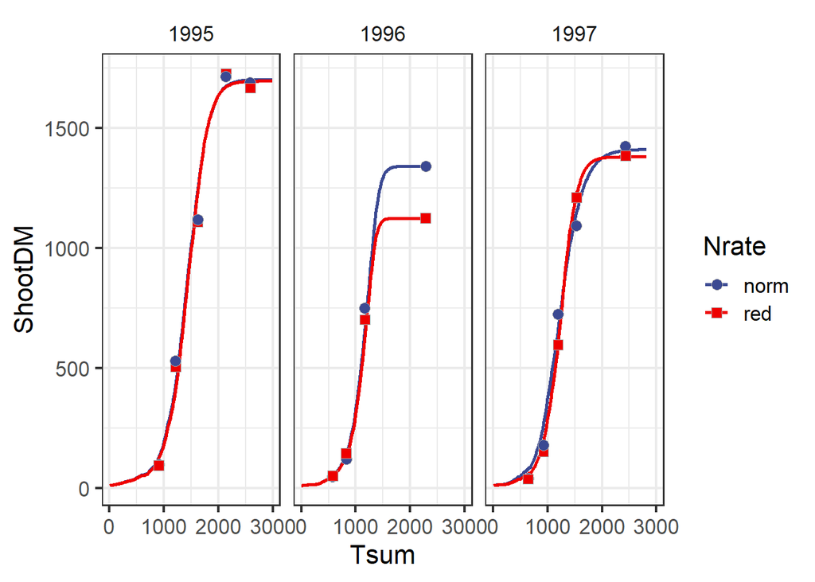

Figure 7: Shoot dry matter measured (points) and predicted by a fitted Richards-equation for winter wheat with normal and reduced nitrogen fertilisation and from three consecutive years

```r
p <- ggplot(data = AllShootSim)
p <- p + theme_bw(base_size = 16)
p <- p + geom_line(aes(x=Tsum, y=ShootDM, color=Nrate), size=1)
p <- p + geom_point(data = ShootDM, aes(x=Tsum, y=ShootDM, fill=Nrate, shape=Nrate), color="darkgrey", size=3)
p <- p + scale_shape_manual(values = MyShapes)
p <- p + scale_color_aaas()
p <- p + scale_fill_aaas()
p <- p + facet_grid(cols = vars(Year))
p <- p + theme(strip.background = element_blank())
p
```

## 2.7 Helper functions

The following helper functions are used to calculate the root length density (RLD) from the shoot dry matter growth rate and the specific root length.

### 2.7.1 R Function WLD_z_t_F

The function `WLD_z_t_F` (Equation 9) calculates the root length density (RLD) for a given depth increment. The code is given in the file `RutheRootModelFunctions.R`.

### 2.7.2 R function RootModDM

The function `RootModDM` calculates the root length densities (RLD) over 15 cm depth increments up to 120 cm for each day of the input data frame. The code is given in the file `RutheRootModelFunctions.R`. An example for the application of the function is given in the following code chunk.

```r
source("RutheRootModelFunctions.R")

# paramter values
k_zb    <-  0.107 # [cm.°C*d-1]
Ratio   <- 0.01731 # [-]
sp_WL   <-  7000 # [cm.gDM-1]
zr_0    <-  2 # [cm]
zrmax   <-  160 # [-]
Tbase <- 0 # [°C]
fFineRoot0  <-  0.653
fFineRootDec    <-  0.000501


df <- AllShootSim %>% filter(Nrate=="norm", Year==1995) %>%
  dplyr::select(Date, TMPM, Tsum, dW_dt,  ShootDM, ID) %>%
  mutate(zr=0, f_root=0, dWt_dt=0, DM_root=0, WL=0, rld_15=0, rld_30=0, rld_45=0,
         rld_60=0, rld_75=0, rld_90=0, rld_105=0, rld_120=0)

test <- RootModDM (df, Tbase, zrmax, k_zb, Ratio, fFineRoot0, fFineRootDec, sp_WL )
```

As an example the root length density (RLD) is shown for the year 1995 and N fertilisation level “normal” (Figure 8). The data are shown for the depth increments of 15 cm. The data are shown as function of date and depth.

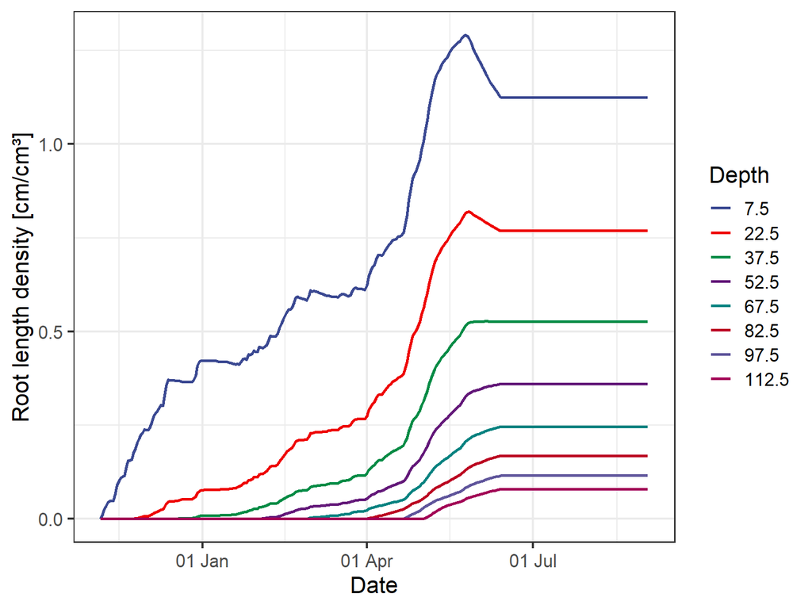

Figure 8: Root length density (RLD) in cm/cm³ as function of date and depth. The data are simulated with the RootModDM function. The data are shown for the year 1995 and N fertilisation level ‘normal’.

```r
illu <- test %>% pivot_longer(cols = c(rld_15, rld_30, rld_45, rld_60, rld_75, rld_90, rld_105, rld_120), names_to = "Depth", names_prefix = "rld_", values_to = "rld")
illu$Depth <- as.numeric(illu$Depth)
illu$Depth <- illu$Depth - 7.5
illu$Depth <- as.factor(illu$Depth)

p <- ggplot(data = illu)
p <- p + theme_bw(base_size = 16)
p <- p + geom_line(aes(x=Date, y=rld, color=Depth), size=1)
p <- p + scale_color_aaas()
#p <- p + scale_fill_aaas()
p <- p + scale_x_date(date_labels = "%d %b")
p <- p + xlab("Date") + ylab("Root length density [cm/cm³]")
p
```

### 2.7.3 R function wrapper.RootModDM

In order to fit the model to the data we need to define a wrapper function for the `nls` function. The wrapper function is defined in the file `RutheRootModelFunctions.R`. The following code chunk shows the application of the wrapper function. It returns a vector with the simulated root length density (RLD) for each observation date and depth.

```r
rld.data$obsIDs <- paste(rld.data$Nrate, rld.data$Date, rld.data$Depth, sep="_")
rld.data <- rld.data %>% arrange(unique(obsIDs))

fFineRoot0 <- 0.653
fFineRootDec <- 0.000501
Ratio <- 0.0125



fits <- nls.wrapper.RootModDM(df_ext=AllShootSim,
                          Tbase=Tbase,
                          zrmax= 180,
                          k_zb=k_zb,
                          Ratio=Ratio,
                          fFineRoot0= fFineRoot0,
                          fFineRootDec=fFineRootDec,
                          sp_WL=7000)

#fits$year <- as.factor(year(fits$Date))
#fits$Depth <- as.numeric(fits$Depth)
#p <- ggplot(data=fits)
#p <- p + theme_bw(base_size = 16)
#p <- p + geom_point(aes(x=Depth, y=rld), size=3)
#p <- p + coord_flip()
#p <- p + scale_x_reverse(limits = c(120,0), breaks = seq(0, 120, 20))
#p <- p + scale_y_log10(breaks = MyBreaks, minor_breaks=minor_breaks)
#p <- p + facet_grid( cols=vars(year), rows=vars(Nrate))
#p
```

The simulated root length density (RLD) is shown in Figure 9. With the default parameters, the fit is not perfect.

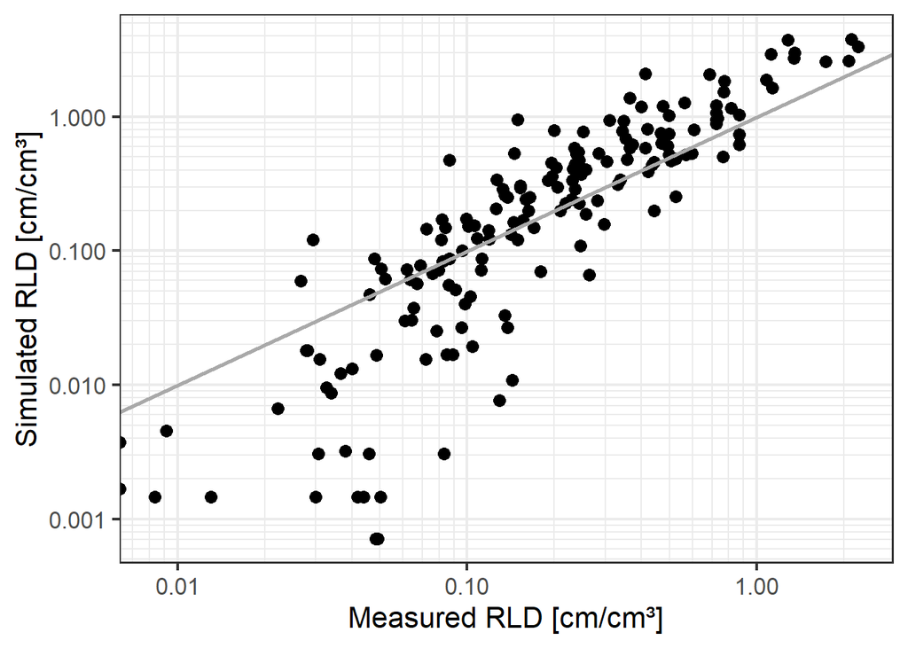

Figure 9: Mesured vs. simulated Root length density (RLD) in cm/cm³. The data are simulated with the RootModDM function.

```r
illu <- data.frame(fit=fits, meas=rld.data$rld, obsIDs=rld.data$obsIDs)

p <- ggplot(data = illu)
p <- p + theme_bw(base_size = 16)
p <- p + geom_point(aes(x=fit, y=meas), size=3)
p <- p + geom_abline(intercept = 0, slope = 1, color="darkgrey", size=1)
p <- p + scale_x_log10(breaks = MyBreaks, minor_breaks=minor_breaks)
p <- p + scale_y_log10(breaks = MyBreaks, minor_breaks=minor_breaks)
p <- p + xlab("Measured RLD [cm/cm³]") + ylab("Simulated RLD [cm/cm³]")
p <- p + scale_color_aaas()
p <- p + scale_fill_aaas()
p
```

# 3 Optimisation of model parameters

The model parameters are subject to further optimisation. The parameters are estimated by minimising the sum of squares of the differences between the measured and simulated root length density (RLD). The optimisation is done with either the `nls` or the `optim` function. For both approaches additionally wrapper functions had to be defined. The wrapper functions are defined in the file `RutheRootModelFunctions.R`.

## 3.1 NLS based optimisation

The `nls` algorithm is based on derivatives and is sensitive to the starting values. As an example only the optimisation of the parameter `Ratio` is shown. Tests with more parameters were not very successful yet.

```r
nls.control(minFactor = 1/2048)
```

```
$maxiter
[1] 50

$tol
[1] 1e-05

$minFactor
[1] 0.0004882812

$printEval
[1] FALSE

$warnOnly
[1] FALSE

$scaleOffset
[1] 0

$nDcentral
[1] FALSE
```

```r
Meas <- rld.data$rld
# Re-fit the model with artificial changed parameters ###########

RootMod.nls<- nls(formula = Meas~nls.wrapper.RootModDM(df_ext=AllShootSim,
                                                   Tbase=Tbase,
                                                   zrmax=140,
                                                   k_zb=k_zb,
                                                   Ratio=Ratio,
                                                   fFineRoot0=fFineRoot0,
                                                   fFineRootDec = fFineRootDec,
                                                   sp_WL=7000),
                  data = list(Meas),
                  start = list(Ratio=Ratio ) )


# ,  fFineRoot0=1.01*fFineRoot0,fFineRootDec=1.01*fFineRootDec



summary(RootMod.nls)
```

```
Formula: Meas ~ nls.wrapper.RootModDM(df_ext = AllShootSim, Tbase = Tbase,
    zrmax = 140, k_zb = k_zb, Ratio = Ratio, fFineRoot0 = fFineRoot0,
    fFineRootDec = fFineRootDec, sp_WL = 7000)

Parameters:
      Estimate Std. Error t value Pr(>|t|)
Ratio 0.006222   0.002949    2.11   0.0363 *
---
Signif. codes:  0 '***' 0.001 '**' 0.01 '*' 0.05 '.' 0.1 ' ' 1

Residual standard error: 0.444 on 169 degrees of freedom

Number of iterations to convergence: 9
Achieved convergence tolerance: 6.527e-06
```

```r
Ratio <- summary(RootMod.nls)$coefficients[1]
```

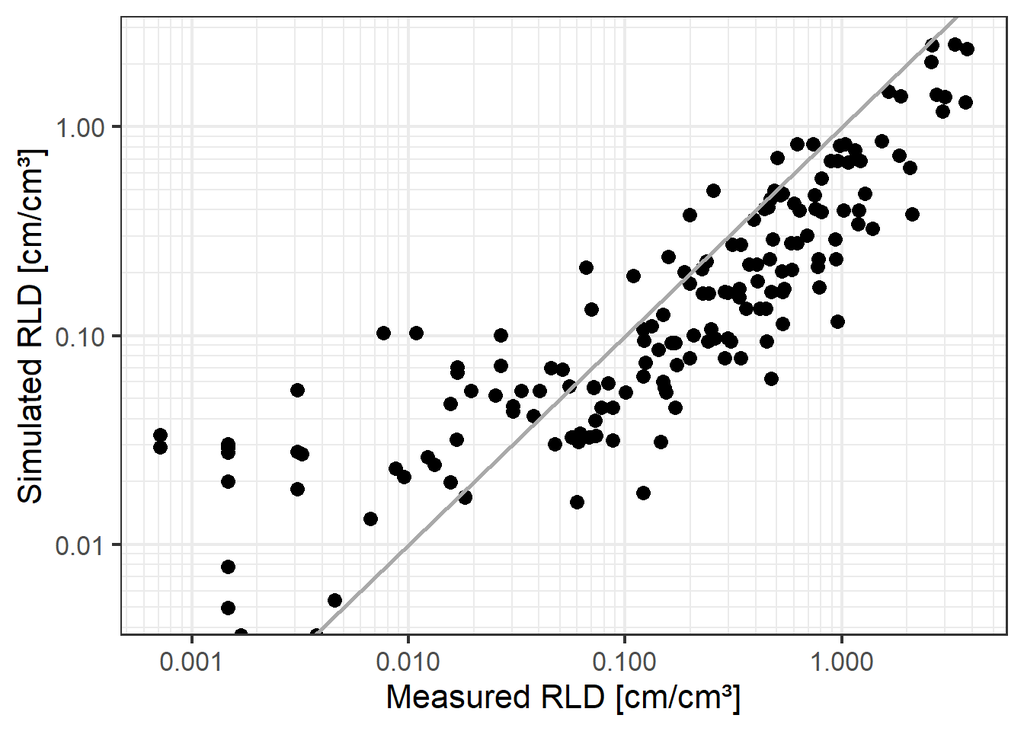

```r
fits <- nls.wrapper.RootModDM(df_ext=AllShootSim,
                          Tbase=Tbase,
                          zrmax= 140,
                          k_zb=k_zb,
                          Ratio=Ratio,
                          fFineRoot0= fFineRoot0,
                          fFineRootDec=fFineRootDec,
                          sp_WL=7000)


illu <- data.frame(fit=fits, meas=rld.data$rld, obsIDs=rld.data$obsIDs)

p <- ggplot(data = illu)
p <- p + theme_bw(base_size = 16)
p <- p + geom_point(aes(x=meas, y=fit), size=3)
p <- p + geom_abline(intercept = 0, slope = 1, color="darkgrey", size=1)
p <- p + scale_x_log10(breaks = MyBreaks, minor_breaks=minor_breaks)
p <- p + scale_y_log10(breaks = MyBreaks, minor_breaks=minor_breaks)
p <- p + xlab("Measured RLD [cm/cm³]") + ylab("Simulated RLD [cm/cm³]")
p <- p + scale_color_aaas()
p <- p + scale_fill_aaas()
p
```

## 3.2 optim Optimisation

The `optim` function is a general purpose optimisation function. The default optimisation algorithm is the Nelder-Mead simplex algorithm. The function is not as sensitive to the starting values. The function is here be for the optimisation of the paramters `Ratio`, `fFineFoot0` and `fFineRootDec`. The optim function is expecting a single value for the objective to be minimised. For this the wrapper function `optim.wrapper.RootModDM` is defined in the file `RutheRootModelFunctions.R`. The objective value is calculated from the sum of the squared differences between the logarithms of the measured and simulated root length density (RLD).

```r
params <- vector()
params[1] <- Ratio
params[2] <- fFineRoot0
params[3] <- fFineRootDec

Objective <- optim.wrapper.RootModDM(params)


#result <- optim(par = params, fn = optim.wrapper.RootModDM, method = "SANN")
result <- optim(par = params, fn = optim.wrapper.RootModDM)

Ratio_save <- result$par[1]
fFineRoot0_save <- result$par[2]
fFineRootDec_save <- result$par[3]

result
```

```
$par
[1] 0.0027037690 0.4160736603 0.0001682796

$value
[1] 178.8615

$counts
function gradient
     166       NA

$convergence
[1] 0

$message
NULL
```

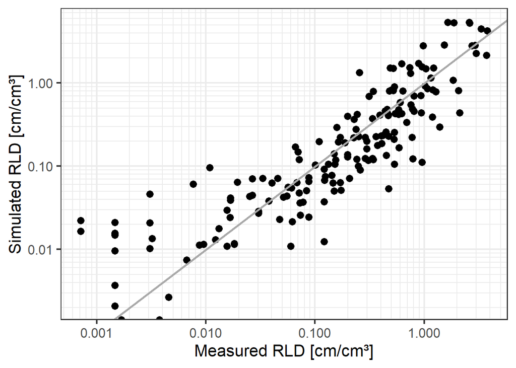

```r
Ratio <- result$par[1]
fFineRoot0 <- result$par[2]
fFineRootDec <- result$par[3]

#Ratio <- Ratio_save
#fFineRoot0 <- fFineRoot0_save
#fFineRootDec <- fFineRootDec_save


fit <- nls.wrapper.RootModDM(df_ext=AllShootSim,
                          Tbase=Tbase,
                          zrmax= 140,
                          k_zb=k_zb,
                          Ratio=Ratio,
                          fFineRoot0= fFineRoot0,
                          fFineRootDec=fFineRootDec,
                          sp_WL=7000)

illu <- data.frame(fit=fit, meas=rld.data$rld, obsIDs=rld.data$obsIDs)
p <- ggplot(data = illu)
p <- p + theme_bw(base_size = 16)
p <- p + geom_point(aes(x=meas, y=fit), size=3)
p <- p + geom_abline(intercept = 0, slope = 1, color="darkgrey", size=1)
p <- p + scale_x_log10(breaks = MyBreaks, minor_breaks=minor_breaks)
p <- p + scale_y_log10(breaks = MyBreaks, minor_breaks=minor_breaks)
p <- p + xlab("Measured RLD [cm/cm³]") + ylab("Simulated RLD [cm/cm³]")
p <- p + scale_color_aaas()
p <- p + scale_fill_aaas()
p
```

## 4 References

Barraclough, P.B., 1984. The growth and activity of winter wheat roots in the field: Root growth of high-yielding crops in relation to shoot growth. Journal of agricultural Science (Camb.) 103, 439–442.

Bragg, P.L., Govi, G., Cannell, R.Q., 1983. A comparison of methods, including angled and vertical minirhizotrons, for studying root growth and distribution in a spring oat crop. Plant and Soil 73, 435–440. https://doi.org/10.1007/bf02184322

Gerwitz, A., Page, E.R., 1974. An empirical mathematical model to describe plant root systems. J.appl.Ecol. 11, 773–781.

Greenwood, D.J., Gerwitz, A., Stone, D.A., Barnes, A., 1982. Root development of vegetable crops. Plant and Soil 68, 75–96.

Jaafar, M.N., Stone, L.R., Goodrum, D.E., 1993. Rooting depth and dry matter development of sunflower. Agronomy Journal 85, 281–286.

Kage, H., 2001. Improving nitrogen use efficiency of intensive cropping systems (Habilitationsschrift). Hannover, University of; University of Hannover, Hannover.

Kage, H., Ehlers, W., 1996. Does transport of water to roots limit water uptake of field crops? Zeitschrift Fur Pflanzenernahrung und Bodenkunde 159, 583–590.

Kage, H., Kochler, M., Stutzel, H., 2000. Root growth of cauliflower (brassica oleracea l. Botrytis) under unstressed conditions: Measurement and modelling. Plant and Soil 223, 131–145.

Maertens, C., 1987. Ways of using endoscopy to determine growth and quality of root systems, in: American_Society_of_Agronomy (Ed.), Minirhizotron Observation Tubes: Methods and Applications for Measuring Rhizosphere Dynamics, ASA Special Publication. American_Society_of_Agronomy, Madison, pp. 31–37.

Savin, R., Hall, A.J., Satorre, E.H., 1994. Testing the root growth subroutine of the CERES-wheat model for 2 cultivars of different cycle length. Field Crops Research 38, 125–133.

Siddique, K.H.M., Belford, R.K., Tennant, D., 1990. Root: Shoot ratios of old and modern, tall and semi-dwarf wheats in a mediterranean environment. Plant and Soil 121, 89–98.

Thornley, J.H.M., Johnson, I.R., 1990. Plant and crop modelling. A mathematical approach to plant and crop physiology. Clarendon Press, Oxford.

Thorup-Kristensen, K., 1998. Root growth of green pea (pisum sativum l.) genotypes. Crop Science 38, 1445–1451.

Thorup-Kristensen, K., Nielsen, N.E., 1998. Modelling and measuring the effect of nitrogen catch crops on the nitrogen supply for succeeding crops. Plant and Soil 203, 79–89.